# ACP2

2022-12-24

L’analyse en composantes principales(ACP): est l’une des méthodes d’analyse de données multivariées les plus fréquemment utilisées. Elle permet d’étudier des ensembles de données multidimensionnelles avec des variables quantitatives. Elle est largement utilisée en biostatistique, en marketing, en sociologie et dans de nombreux autres domaines.

l’objectif de l’ACP: L’ACP permet de décrire un jeu de données, de le résumer, d’en réduire la dimensionnalité.

Etapes de l’ACP: 1.L’intérêt de l’ACP

2.Pertinence de l’ACP

3.Choix du nombre d’axes à retenir

4.Interprétation de la carte des variables

5.Interprétation de la carte des individus

l’objectifs de l’ACP à propos nos données est de : -Etude des individus : Y a-t-il des similarités entre les individus pour toutes les variables ? Peut-on opposer un groupe d’individus à un autre ? -Etude des variables : on étudie les liaisons linéaires entre les variables. Les objectifs sont de résumer la matrice des corrélations. -Lien entre les deux études : peut-on caractériser des groups d’individus par des variables ?

#Importation et explorer les données:

```r
library(readxl)#pour lire le fichier excel
```

```r
library(corrplot) #pour faire la matrice de corrélation
library(RColorBrewer) #pour les couleurs
library(factoextra)#qui permet de mettre joliment en forme des résultats d'ACP
library(FactoMineR)#qui permet de mettre en oeuvre des méthodes analyses de données
```

#1. Linteret de l’ACP

```r
#Lire les données:
library("xlsx")
data <- read.xlsx('C:/Users/21656/Documents/Salle_de_sport.xlsx',1)  # read the data contains in Sheet1
head(data)
```

```
##            Horodateur  Sexe                    Age Acitivité.SportiveO.N
## 1 2022-12-21 23:39:53 Homme entre 18 ans et 30 ans                   Oui
## 2 2022-12-21 23:52:46 Homme entre 18 ans et 30 ans                   Oui
## 3 2022-12-21 23:53:37 Femme entre 18 ans et 30 ans                   Non
## 4 2022-12-21 23:55:14 Homme entre 18 ans et 30 ans                   Oui
## 5 2022-12-21 23:59:13 Homme entre 18 ans et 30 ans                   Oui
## 6 2022-12-21 23:59:54 Homme entre 18 ans et 30 ans                   Non
##                                          Activité.Sportive
## 1                          Sports de force (fitness, etc.)
## 2 Sports collectifs (football, Basketball, handball, etc.)
## 3                   Je ne pratique pas d’activité sportive
## 4 Sports collectifs (football, Basketball, handball, etc.)
## 5 Sports collectifs (football, Basketball, handball, etc.)
## 6                   Je ne pratique pas d’activité sportive
##   Fréquenté.une.salle.de.sport.           Avantages
```

[output cut: 76 more lines]

```r
#dimension des individus et des varaibles:
dim(data)
```

```
## [1] 34 37
```

34 individus et 37 variables.

```r
#Pour voir les variables :
names(data)
```

```
##  [1] "Horodateur"
##  [2] "Sexe"
##  [3] "Age"
##  [4] "Acitivité.SportiveO.N"
##  [5] "Activité.Sportive"
##  [6] "Fréquenté.une.salle.de.sport."
##  [7] "Avantages"
##  [8] "Cours.Femmes"
##  [9] "Budget"
## [10] "Fréquence.d.entrainement"
## [11] "Statut"
## [12] "Type.de.Cours"
## [13] "Nouvelle.salle.de.sport"
## [14] "Poids.libre"
## [15] "Appareils.à.musculation"
```

[output cut: 22 more lines]

```r
summary(data)
```

```
##    Horodateur                         Sexe               Age
##  Min.   :2022-12-21 23:39:53.55   Length:34          Length:34
##  1st Qu.:2022-12-22 00:25:36.67   Class :character   Class :character
##  Median :2022-12-22 06:20:11.72   Mode  :character   Mode  :character
##  Mean   :2022-12-22 20:07:01.15
##  3rd Qu.:2022-12-23 17:29:27.75
##  Max.   :2022-12-24 23:34:02.14
##  Acitivité.SportiveO.N Activité.Sportive  Fréquenté.une.salle.de.sport.
##  Length:34             Length:34          Length:34
##  Class :character      Class :character   Class :character
##  Mode  :character      Mode  :character   Mode  :character
##
##
##
##   Avantages         Cours.Femmes          Budget
##  Length:34          Length:34          Length:34
##  Class :character   Class :character   Class :character
##  Mode  :character   Mode  :character   Mode  :character
##
##
##
##  Fréquence.d.entrainement    Statut          Type.de.Cours
##  Length:34                Length:34          Length:34
##  Class :character         Class :character   Class :character
##  Mode  :character         Mode  :character   Mode  :character
##
##
##
##  Nouvelle.salle.de.sport  Poids.libre    Appareils.à.musculation
##  Min.   :1.000           Min.   :1.000   Min.   :1.000
##  1st Qu.:3.000           1st Qu.:2.000   1st Qu.:2.000
##  Median :3.000           Median :3.000   Median :4.000
##  Mean   :3.324           Mean   :2.853   Mean   :3.294
##  3rd Qu.:4.750           3rd Qu.:4.000   3rd Qu.:4.000
##  Max.   :5.000           Max.   :5.000   Max.   :5.000
##  Machines.de.cardio Cours.Collectif Sport.de.combat Coaching.Privé
##  Min.   :1.000      Min.   :1.000   Min.   :1.000   Min.   :1.000
##  1st Qu.:3.000      1st Qu.:1.000   1st Qu.:1.000   1st Qu.:2.000
##  Median :4.000      Median :2.000   Median :2.000   Median :3.000
##  Mean   :3.676      Mean   :2.353   Mean   :2.441   Mean   :2.706
```

[output cut: 36 more lines]

```
##  Max.   :5.000                              Max.   :5.000
##  Design.de.la.salle Coachs.professionnels Physiothérapie.et.réhabilitation
##  Min.   :1.000      Min.   :1.000         Min.   :1.000
##  1st Qu.:2.000      1st Qu.:2.000         1st Qu.:2.250
##  Median :3.000      Median :3.500         Median :4.000
##  Mean   :2.853      Mean   :3.324         Mean   :3.324
##  3rd Qu.:4.000      3rd Qu.:4.000         3rd Qu.:4.000
##  Max.   :4.000      Max.   :5.000         Max.   :5.000
##  Ambiance.accueillante.et.inclusive
##  Min.   :1.000
##  1st Qu.:3.000
##  Median :4.000
##  Mean   :3.588
##  3rd Qu.:4.750
##  Max.   :5.000
```

#2. Pertinence de l’ACP:

```r
X1 = as.matrix(data[,c(28:37)])
#Matrice de corrélation:
M1<-cor(X1)
M1
```

```
##                                            Horaires.d.ouverture Localisation
## Horaires.d.ouverture                                  1.0000000    0.5061012
## Localisation                                          0.5061012    1.0000000
## Des.prix.attractifs                                   0.5218943    0.7102035
## Propreté.des.salles.et.des.vestiaires                 0.5898309    0.5091408
## Qualité.des.infrastructures.et.équipements            0.4921680    0.4877224
## Variation.des.équipements                             0.4171397    0.5990033
## Design.de.la.salle                                    0.2860424    0.2228706
## Coachs.professionnels                                 0.2674848    0.5803610
## Physiothérapie.et.réhabilitation                      0.3037534    0.4668291
## Ambiance.accueillante.et.inclusive                    0.3357329    0.3119747
##                                            Des.prix.attractifs
## Horaires.d.ouverture                                 0.5218943
## Localisation                                         0.7102035
## Des.prix.attractifs                                  1.0000000
## Propreté.des.salles.et.des.vestiaires                0.7271868
## Qualité.des.infrastructures.et.équipements           0.8125091
## Variation.des.équipements                            0.7894327
## Design.de.la.salle                                   0.4454856
## Coachs.professionnels                                0.5781633
## Physiothérapie.et.réhabilitation                     0.4405286
## Ambiance.accueillante.et.inclusive                   0.3368599
##                                            Propreté.des.salles.et.des.vestiaires
## Horaires.d.ouverture                                                   0.5898309
## Localisation                                                           0.5091408
## Des.prix.attractifs                                                    0.7271868
## Propreté.des.salles.et.des.vestiaires                                  1.0000000
## Qualité.des.infrastructures.et.équipements                             0.7634604
## Variation.des.équipements                                              0.4918240
## Design.de.la.salle                                                     0.2892437
## Coachs.professionnels                                                  0.3231672
## Physiothérapie.et.réhabilitation                                       0.2924189
## Ambiance.accueillante.et.inclusive                                     0.4263393
##                                            Qualité.des.infrastructures.et.équipements
## Horaires.d.ouverture                                                       0.49216799
## Localisation                                                               0.48772239
## Des.prix.attractifs                                                        0.81250911
## Propreté.des.salles.et.des.vestiaires                                      0.76346040
## Qualité.des.infrastructures.et.équipements                                 1.00000000
## Variation.des.équipements                                                  0.69753566
```

[output cut: 44 more lines]

```
## Design.de.la.salle                                                0.5536931
## Coachs.professionnels                                             0.5406088
## Physiothérapie.et.réhabilitation                                  1.0000000
## Ambiance.accueillante.et.inclusive                                0.4690009
##                                            Ambiance.accueillante.et.inclusive
## Horaires.d.ouverture                                               0.33573291
## Localisation                                                       0.31197475
## Des.prix.attractifs                                                0.33685987
## Propreté.des.salles.et.des.vestiaires                              0.42633934
## Qualité.des.infrastructures.et.équipements                         0.07796807
## Variation.des.équipements                                          0.06479838
## Design.de.la.salle                                                 0.29993330
## Coachs.professionnels                                              0.47335422
## Physiothérapie.et.réhabilitation                                   0.46900088
## Ambiance.accueillante.et.inclusive                                 1.00000000
```

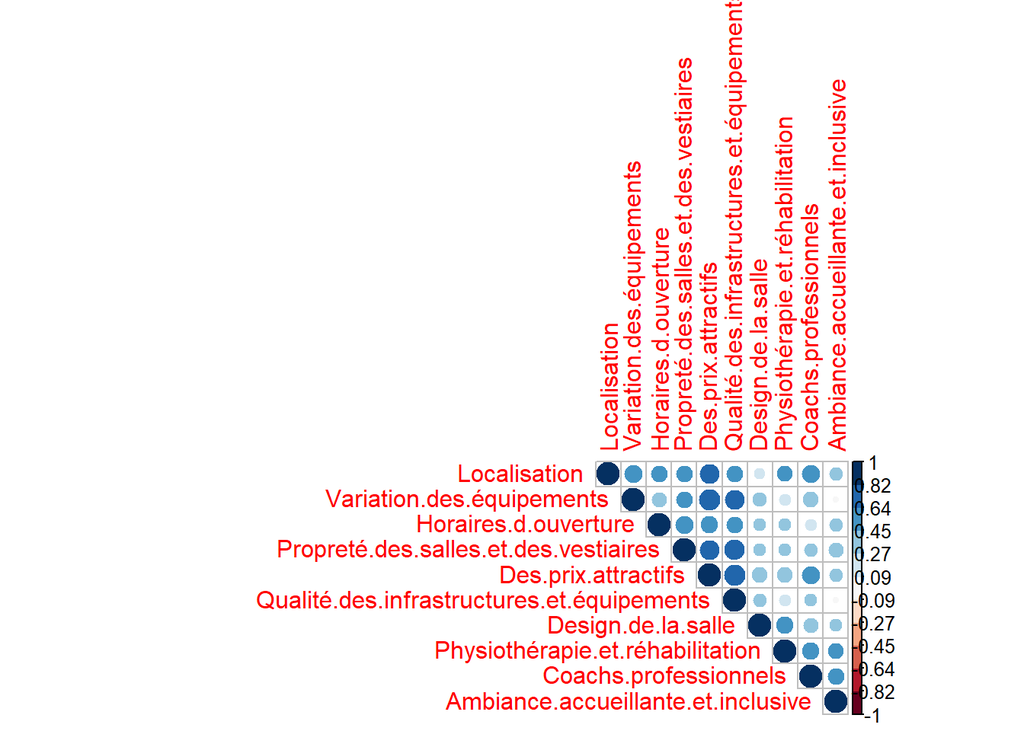

```r
corrplot(M1, type="upper", order="hclust",
         col=brewer.pal(n=11, name="RdBu"))
```

Ce corrgram est pour étudier la corrélation entre les variables: il est clair qu’il existe des corrélations importantes entre des groupes de variables ce qui suggère la pertinence de cette ACP par exemple, on a Proprete des salles et Qualité d’infrastructure ,Localisation et Prix ect…

#3. Choix du nombre d’axes à retenir

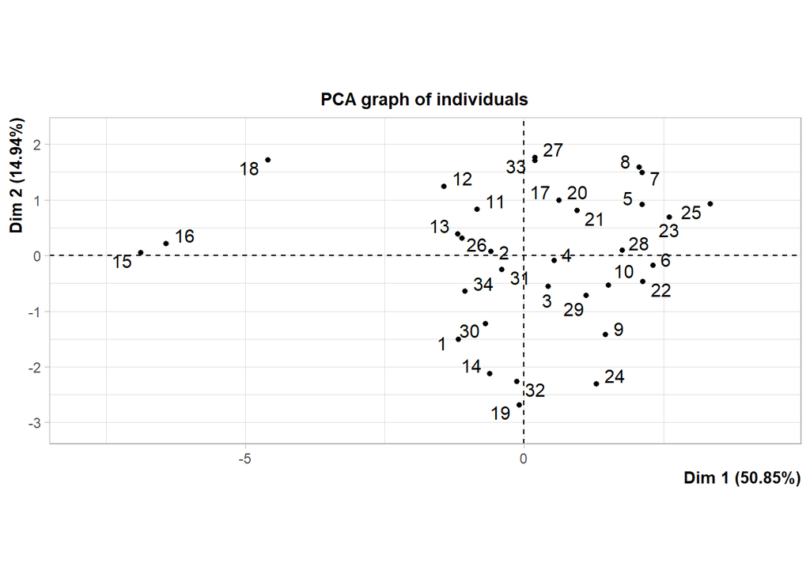

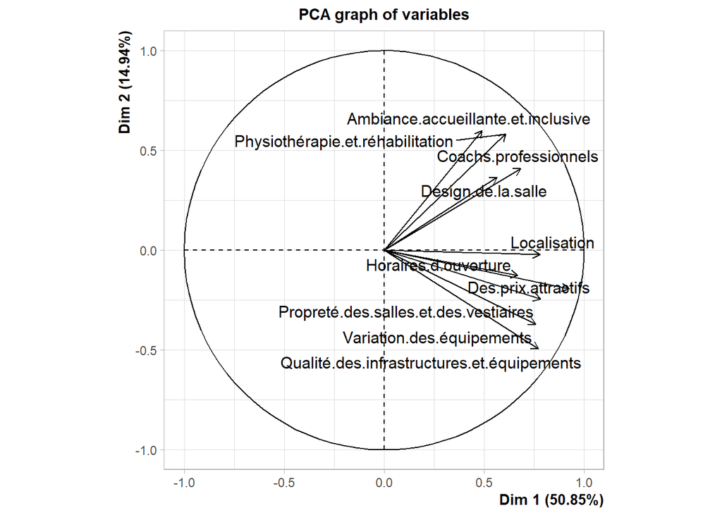

```r
res.pca=PCA(X1,graph = T)
```

Pour choisir le nombre d’axes à retenir , il ya Trois critères devront être utlisés : taux d’inertie cumulé, critère de Kaiser et critère du coude.

```r
#eig: est une matrice de trois colonnes contenants les valeurs propres de l’ACP(eigenvalue), la proportion de variance de chaque composante(percentage of variance) et les variance cumulées par les composantes principales(cumulative percentage of variance.

head(res.pca$eig)
```

```
##        eigenvalue percentage of variance cumulative percentage of variance
## comp 1  5.0853675              50.853675                          50.85367
## comp 2  1.4944903              14.944903                          65.79858
## comp 3  0.9313620               9.313620                          75.11220
## comp 4  0.7792516               7.792516                          82.90471
## comp 5  0.5520479               5.520479                          88.42519
## comp 6  0.4353720               4.353720                          92.77891
```

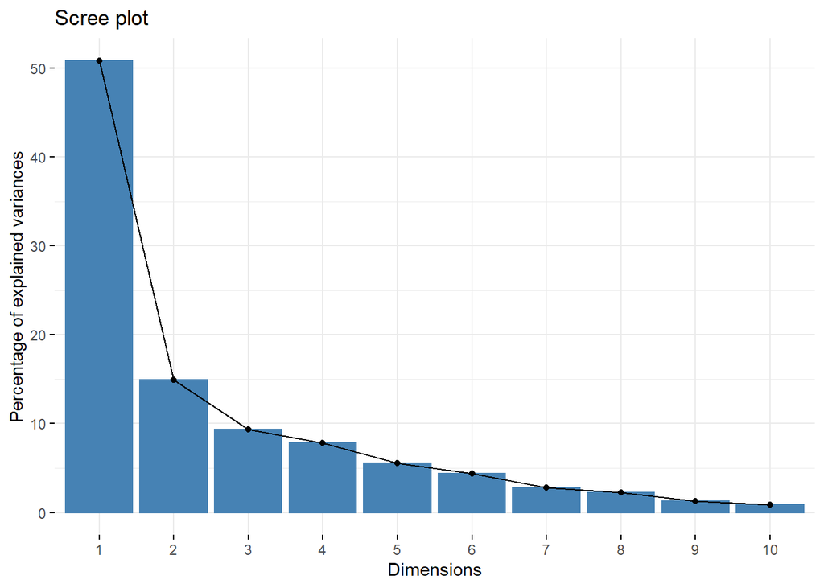

```r
fviz_screeplot(res.pca, ncp=11)
```

Critère de kaiser : on remarque qu’il y 2 axes dont les valeurs propres sont supérieures à 1 donc on retient 2 axes d’après ce critère.

Critère du coude : On remarque que le coude se trouve au niveau du deuxième axe (voir la figure Scree plot), d’après ce critère, on devrait retenir les 2 premiers axes.

#4. Interprétation de la carte des variables:

```r
names(res.pca$var)
```

```
## [1] "coord"   "cor"     "cos2"    "contrib"
```

cor : la corrélations d’une variable avec la composante principale d’un axe coord: la coordonnée de cette variable sur cet axe Cos² : Cosinus carré des variables. Représente la qualité de représentation des variables sur le graphique de l’ACP contrib:contient les contributions (en pourcentage), des variables, aux composantes principales.

Les coordonnées des variables:

```r
res.pca$var$coord
```

```
##                                                Dim.1       Dim.2       Dim.3
## Horaires.d.ouverture                       0.6677114 -0.12541859  0.43336896
## Localisation                               0.7789678 -0.02127092 -0.01515066
## Des.prix.attractifs                        0.9242806 -0.19284523 -0.09387947
## Propreté.des.salles.et.des.vestiaires      0.7822857 -0.24523433  0.39223821
## Qualité.des.infrastructures.et.équipements 0.7728947 -0.49463016 -0.03104774
## Variation.des.équipements                  0.7578589 -0.37043554 -0.35039912
## Design.de.la.salle                         0.5647458  0.36515396 -0.37083239
## Coachs.professionnels                      0.6826079  0.40949642 -0.23181946
## Physiothérapie.et.réhabilitation           0.6085709  0.58298474 -0.13728690
## Ambiance.accueillante.et.inclusive         0.4893939  0.59849928  0.49680126
##                                                  Dim.4        Dim.5
## Horaires.d.ouverture                        0.14004054  0.507375435
## Localisation                               -0.46546613  0.244027058
## Des.prix.attractifs                        -0.04810917 -0.135808903
## Propreté.des.salles.et.des.vestiaires       0.16182233 -0.234904863
## Qualité.des.infrastructures.et.équipements  0.18149551 -0.156423869
## Variation.des.équipements                  -0.09205067 -0.008742069
## Design.de.la.salle                          0.57534689  0.035181465
## Coachs.professionnels                      -0.36229862 -0.141814290
## Physiothérapie.et.réhabilitation            0.09586874  0.197587908
## Ambiance.accueillante.et.inclusive         -0.03989370 -0.276603713
```

L’objet cos2 dans var est une matrice dont les lignes représentent le cos carrés de la variable

```r
res.pca$var$cos2
```

```
##                                                Dim.1        Dim.2        Dim.3
## Horaires.d.ouverture                       0.4458385 0.0157298221 0.1878086554
## Localisation                               0.6067909 0.0004524522 0.0002295426
## Des.prix.attractifs                        0.8542946 0.0371892838 0.0088133554
## Propreté.des.salles.et.des.vestiaires      0.6119709 0.0601398766 0.1538508107
## Qualité.des.infrastructures.et.équipements 0.5973662 0.2446589968 0.0009639622
## Variation.des.équipements                  0.5743502 0.1372224905 0.1227795457
## Design.de.la.salle                         0.3189379 0.1333374140 0.1375166633
## Coachs.professionnels                      0.4659535 0.1676873158 0.0537402600
## Physiothérapie.et.réhabilitation           0.3703585 0.3398712073 0.0188476917
## Ambiance.accueillante.et.inclusive         0.2395064 0.3582013927 0.2468114929
##                                                  Dim.4        Dim.5
## Horaires.d.ouverture                       0.019611353 2.574298e-01
## Localisation                               0.216658722 5.954921e-02
## Des.prix.attractifs                        0.002314492 1.844406e-02
## Propreté.des.salles.et.des.vestiaires      0.026186466 5.518029e-02
## Qualité.des.infrastructures.et.équipements 0.032940620 2.446843e-02
## Variation.des.équipements                  0.008473325 7.642376e-05
## Design.de.la.salle                         0.331024044 1.237735e-03
## Coachs.professionnels                      0.131260287 2.011129e-02
## Physiothérapie.et.réhabilitation           0.009190816 3.904098e-02
## Ambiance.accueillante.et.inclusive         0.001591507 7.650961e-02
```

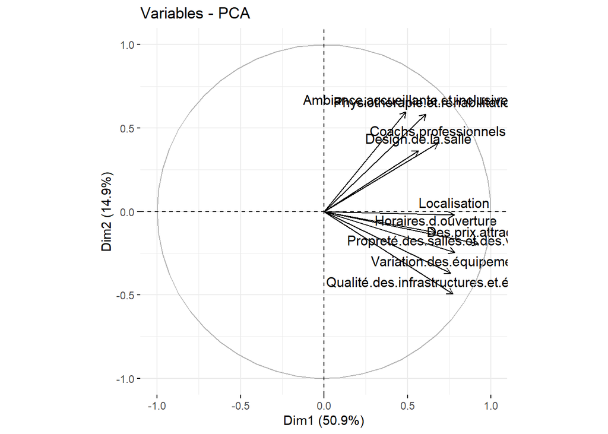

```r
fviz_pca_var(res.pca)
```

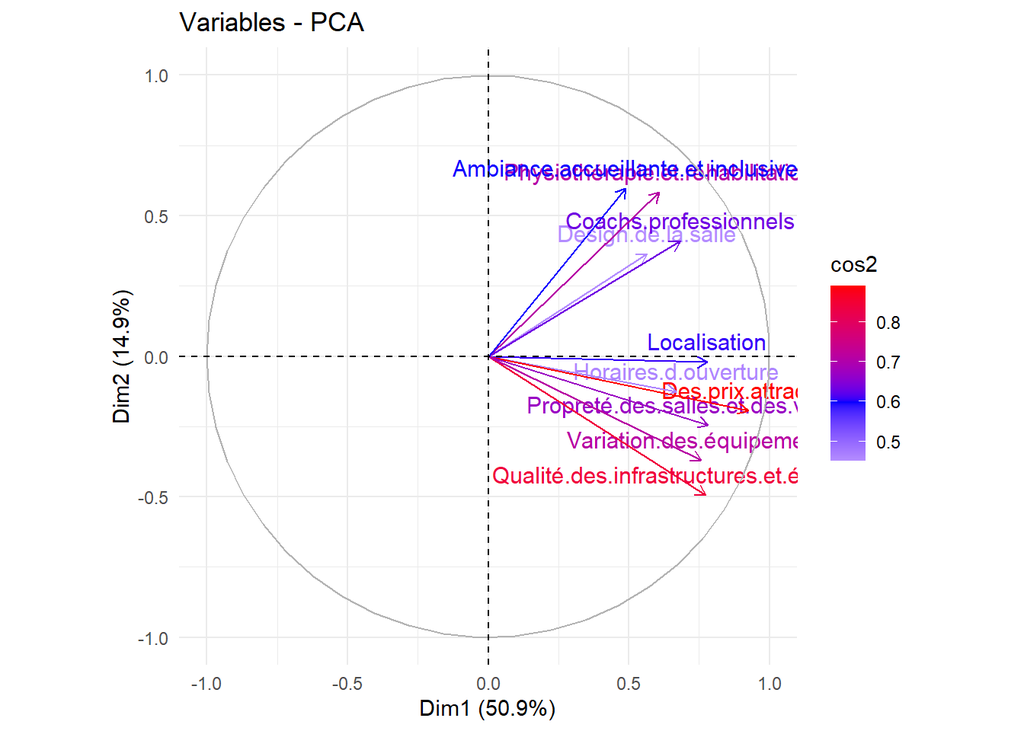

```r
fviz_pca_var(res.pca, col.var="cos2") +
  scale_color_gradient2(low="white", mid="blue",
                        high="red", midpoint=0.6) +
  theme_minimal()
```

#5. Interprétation de la carte des individus:

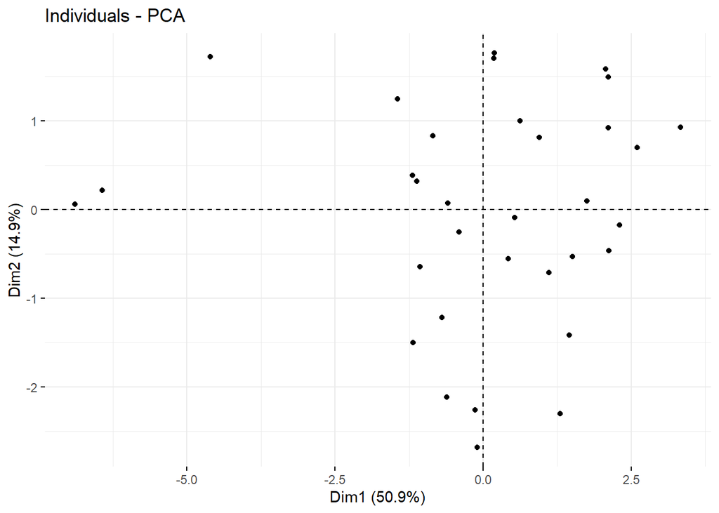

```r
fviz_pca_ind(res.pca,geom = "point",col.ind.sup = 'gray')
```

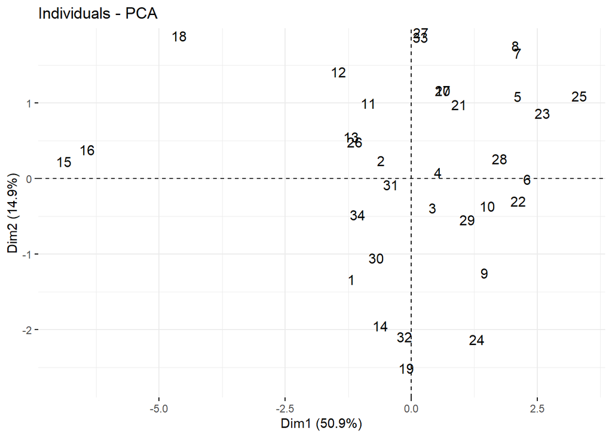

```r
fviz_pca_ind(res.pca,geom = "text",col.ind.sup = 'gray')
```

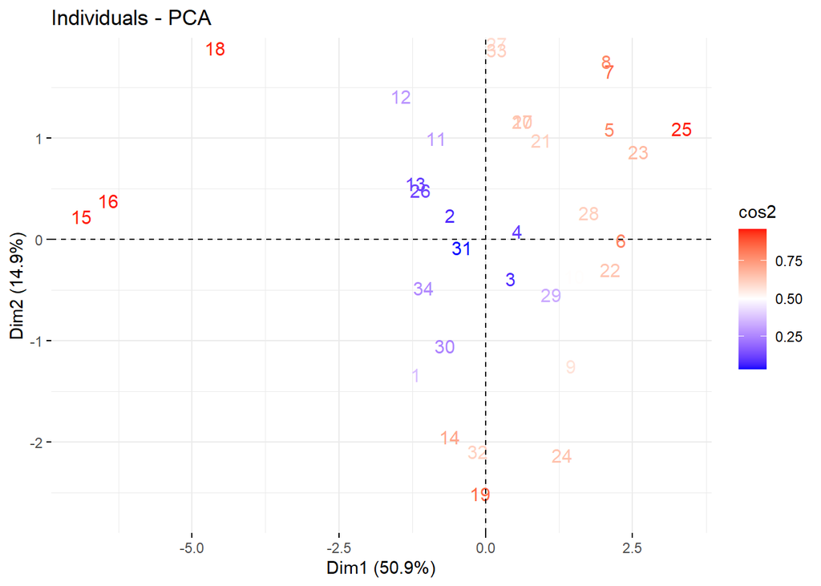

```r
fviz_pca_ind(res.pca,geom = "text",col.ind="cos2")+
scale_color_gradient2(low="blue", mid="white",
                      high="red", midpoint=0.5)
```

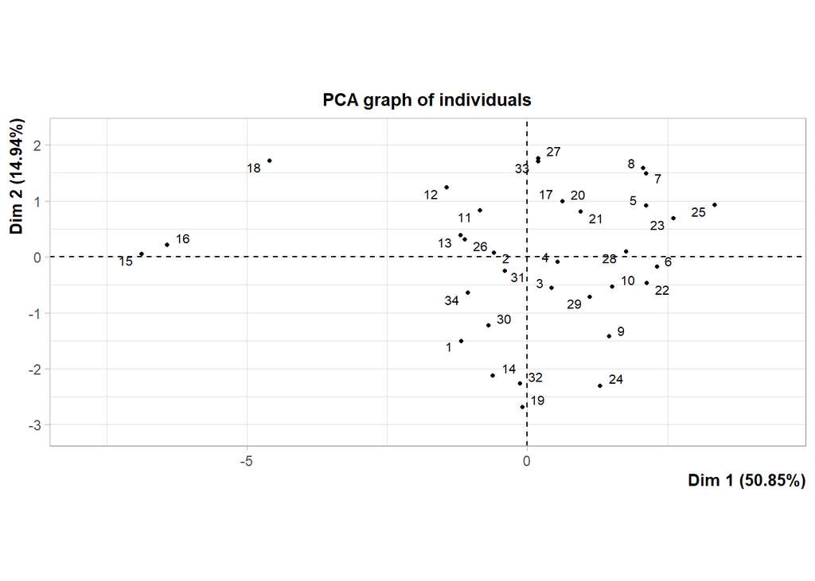

```r
plot.PCA(res.pca, axes=c(1, 2), choix="ind", cex=0.7)
```

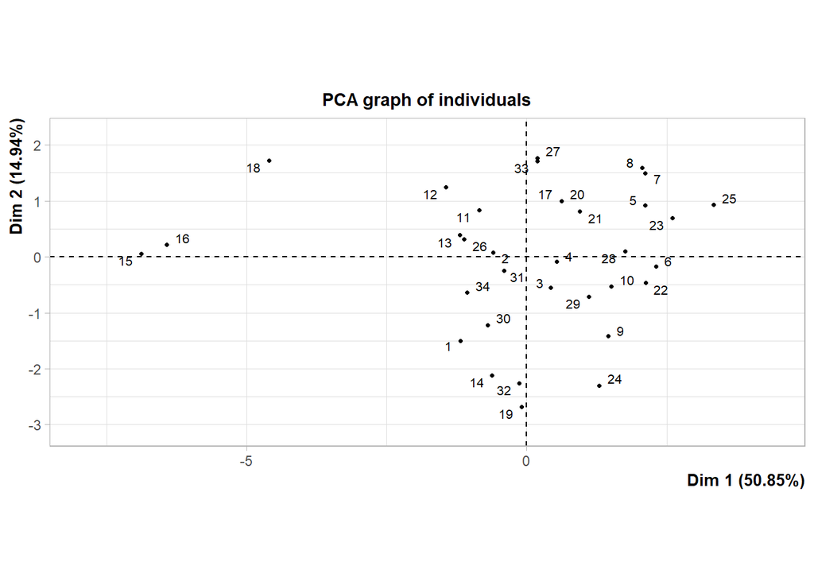

```r
res.pca = PCA(X1, graph=F)
plot(res.pca, choix="ind", cex=0.7)
```